# High School Seniors t Test

```r
library(tidyverse)
library(DT)
library(pander)
library(readr)
library(car)
HSS <- read_csv("Data/HighSchoolSeniors.csv")
#Remember: select "Session, Set Working Directory, To Source File Location", and then play this R-chunk into your console to read the HSS data into R.


HSS <- HSS %>%
  mutate(Sleep_Hours_Schoolnight = as.numeric(Sleep_Hours_Schoolnight))
HSSleep <- HSS %>%
  filter(!is.na(Sleep_Hours_Schoolnight))
HSSleep <- filter(HSSleep, Gender %in% c("Male", "Female"))
```

## Background

The following test was conducted using information collected from high school students via a survey. For more information about this survey, please visit the link provided below

[Survey Information](https://ww2.amstat.org/censusatschool/pdfs/C@SQuestionnaire.pdf)

The information that will be looked at will be the hours of sleep that students get on a school night.

## Questions/Hypotheses

1. Is there a difference in the average number of hours slept on a school night for male and female high school seniors?
2. For the purposes of this analysis, $\alpha$ = 0.05.

## Analysis and Graphics

Below here, a t test will be run and the results will be displayed. In order to visualize the situation better, a boxplot of the data will be displayed as well as a number summary that provides a bit more context than the boxplot.

Note: The “sleep” is only on school nights.

```r
pander(t.test(Sleep_Hours_Schoolnight ~ Gender, data = HSSleep, mu = 0, alternative = "two.sided", conf.level = 0.95))
```

Welch Two Sample t-test: `Sleep_Hours_Schoolnight` by `Gender` (continued below)

| Test statistic | df | P value | Alternative hypothesis |
| --- | --- | --- | --- |
| 0.4969 | 452.6 | 0.6195 | two.sided |

| mean in group Female | mean in group Male |
| --- | --- |
| 6.608 | 6.548 |

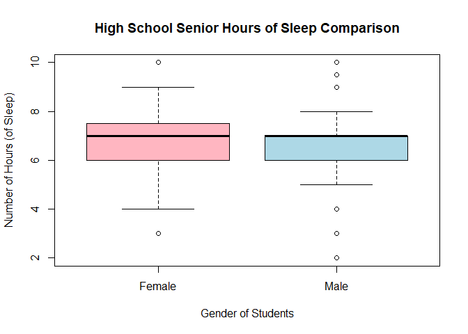

```r
palette(c("lightpink", "lightblue"))
boxplot(Sleep_Hours_Schoolnight ~ Gender, col = palette(), data = HSSleep, ylab = "Number of Hours (of Sleep)", xlab = "Gender of Students", main = "High School Senior Hours of Sleep Comparison")
```

```r
HSSleep %>%
  group_by(Gender) %>%
  summarise(Min= min(Sleep_Hours_Schoolnight), Q1 = quantile(Sleep_Hours_Schoolnight, 0.25), Med = median(Sleep_Hours_Schoolnight), Q3 = quantile(Sleep_Hours_Schoolnight, 0.75), Max = max(Sleep_Hours_Schoolnight), Average = mean(Sleep_Hours_Schoolnight), Sample_Size = n( )) %>%
  pander(caption = "Numerical Summary of Sleep")
```

Numerical Summary of Sleep

| Gender | Min | Q1 | Med | Q3 | Max | Average | Sample_Size |
| --- | --- | --- | --- | --- | --- | --- | --- |
| Female | 3 | 6 | 7 | 7.5 | 10 | 6.608 | 237 |
| Male | 2 | 6 | 7 | 7 | 10 | 6.548 | 219 |

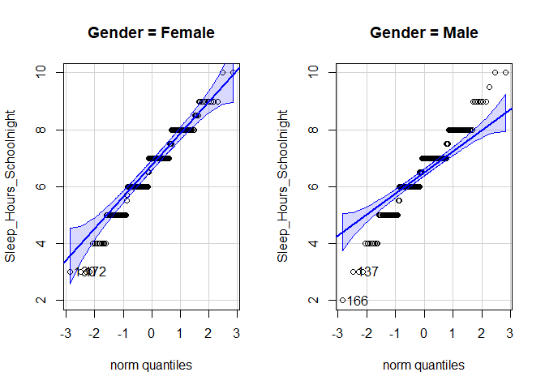

```r
qqPlot(Sleep_Hours_Schoolnight ~ Gender, data = HSSleep)
```

## Conclusion

At the 0.05 significance level, there is insufficient evidence to conclude that there is a difference between the mean number of hours of sleep that male and female students obtain on a school night. This study could be considered reliable if the sample size is the only thing that is examined; however, this is survey data where a lot of values had to be filtered out. The QQ-Plot is not the greatest looking thing, but since the sample size is quite large (237 for the female students and 219 for the male students), the requirements of the test could be considered as satisfied (despite the skew that exists in the data). The conclusion of the study can be solidified by looking at the various summaries above. The averages, according to this data set, are **6.608** for Females and **6.548** for Males (both numbers are measured in hours of sleep on a school night). They are not that far apart (approximately 0.06 hours of difference). Thus, the conclusion doesn’t seem that far-fetched. Conclusion: according to this dataset, there appears to not be a difference between the mean number of hours of sleep obtained by female and male students on school nights.